# Research Memo

Author

Peiqi Li

Published

July 30, 2026

## Research Or Analytical Question

What visual strategy best illustrates the relationship between communication apprehension and transportation use?

## Answer, Response, + Summary of Results

To explore the relationship between communication apprehension and transportation behavior, I created three scatterplots with fitted linear trend lines. Communication apprehension was calculated as the total score across twelve questionnaire items (Q1–Q6 and Q13–Q18) after reverse-coding the six items. Three transportation outcomes were examined: (1) Public transportation use, (2) Ride-share use, (3) Overall transportation use (public transportation use + ride-share use).

```python
import pandas as pd
import numpy as np
import statsmodels.formula.api as smf
import matplotlib.pyplot as plt
df = pd.read_csv("Summer2026DSHBData/PRCAQualtricsExport_FileC.csv")
df = df.iloc[2:].copy()
```

```python
likert_map = {
    "Strongly disagree": 1,
    "Somewhat disagree": 2,
    "Neither agree nor disagree": 3,
    "Somewhat agree": 4,
    "Strongly agree": 5
}

# Communication Apprehension items
discussion_items = [
    "Q1","Q2","Q3","Q4","Q5","Q6",
    "Q13","Q14","Q15","Q16","Q17","Q18"
]

# Convert Likert responses to numeric
for col in discussion_items:
    df[col] = df[col].astype(str).str.strip()
    df[col] = df[col].map(likert_map)

# Reverse-coded items
reverse_items = [
    "Q2","Q4","Q6",
    "Q14","Q16","Q17"
]

for col in reverse_items:
    df[col] = 6 - df[col]

# Composite communication apprehension score
df["Apprehension"] = df[discussion_items].sum(axis=1)

# Public transportation frequency
days_map = {
    "Never": 0,
    "0-1 days a month": 1,
    "2-4 days a month": 2,
    "4-8 days a month": 3,
    "8 or more days a month": 4
}

# Public transportation rides per day
rides_map = {
    "1-2 rides in a typical day": 1,
    "3-4 rides in a typical day": 2,
    "5-6 rides in a typical day": 3,
    "7 or more rides in a typical day": 4
}

df["PublicTransit"] = (
    df["Q26"].map(days_map) +
    df["Q27"].map(rides_map)
)
days_map = {
    "Never": 0,
    "0-1 days a month": 1,
    "2-4 days a month": 2,
    "4-8 days a month": 3,
    "8 or more days a month": 4
}

rides_map = {
    "1-2 rides in a typical day": 1,
    "3-4 rides in a typical day": 2,
    "5-6 rides in a typical day": 3,
    "7 or more rides in a typical day": 4
}

df["RideShare"] = (
    df["Q28"].map(days_map) +
    df["Q29"].map(rides_map)
)
df["TransportationUse"] = (df["PublicTransit"] + df["RideShare"])
```

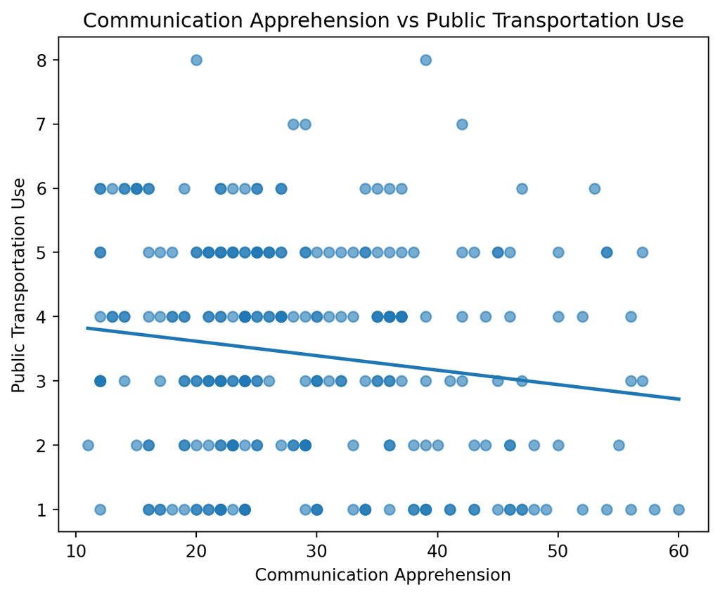

Figure 1: Communication apprehension vs. public transportation use, with fitted linear trend line.

```python
plot_df = df[["Apprehension", "PublicTransit"]].replace([np.inf, -np.inf], np.nan).dropna()

plt.figure(figsize=(6,5))

plt.scatter(
    plot_df["Apprehension"],
    plot_df["PublicTransit"],
    alpha=0.6
)

coef = np.polyfit(
    plot_df["Apprehension"],
    plot_df["PublicTransit"],
    1
)

x = np.linspace(
    plot_df["Apprehension"].min(),
    plot_df["Apprehension"].max(),
    100
)

plt.plot(
    x,
    coef[0]*x + coef[1],
    linewidth=2
)

plt.xlabel("Communication Apprehension")
plt.ylabel("Public Transportation Use")
plt.title("Communication Apprehension vs Public Transportation Use")

plt.tight_layout()
plt.savefig(
    "communication_apprehension_public_transit.png",
    dpi=300,
    bbox_inches="tight"
)
plt.show()
```

The scatterplot displays the relationship between communication apprehension and public transportation use. A fitted linear trend line summarizes the overall pattern in the data.

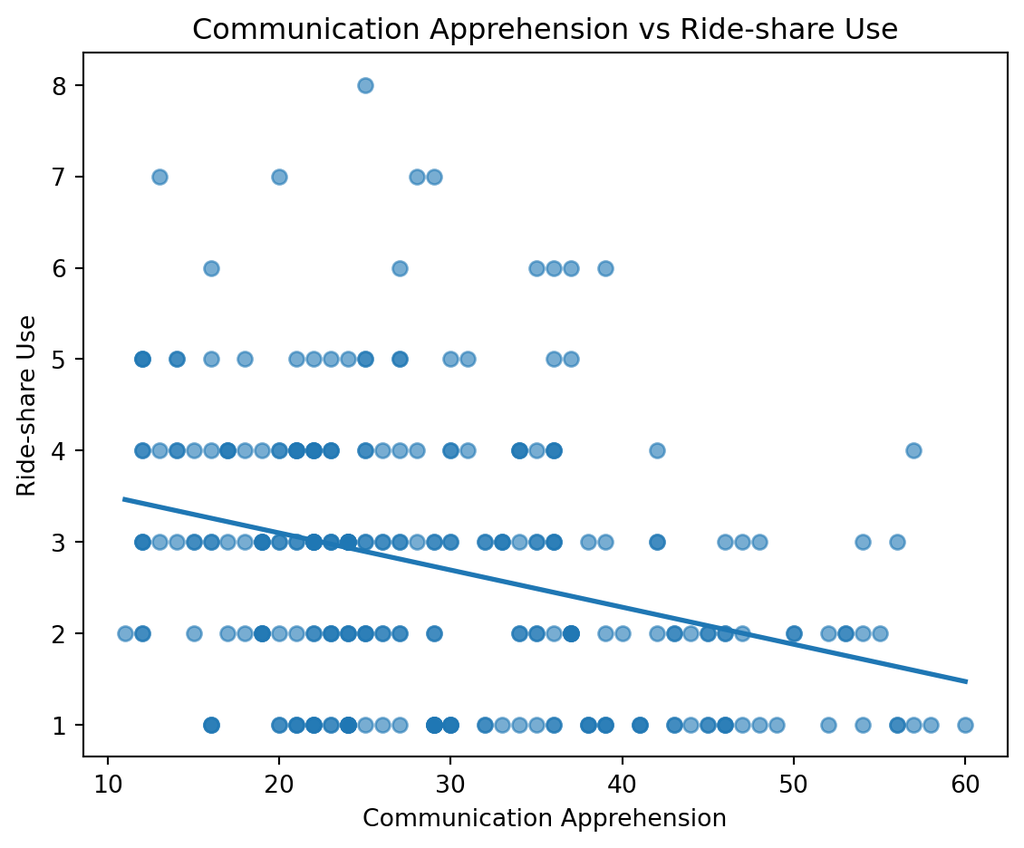

Figure 2: Communication apprehension vs. ride-share use, with fitted linear trend line.

```python
plot_df = df[["Apprehension", "RideShare"]].replace([np.inf, -np.inf], np.nan).dropna()

plt.figure(figsize=(6,5))

plt.scatter(
    plot_df["Apprehension"],
    plot_df["RideShare"],
    alpha=0.6
)

coef = np.polyfit(
    plot_df["Apprehension"],
    plot_df["RideShare"],
    1
)

x = np.linspace(
    plot_df["Apprehension"].min(),
    plot_df["Apprehension"].max(),
    100
)

plt.plot(
    x,
    coef[0]*x + coef[1],
    linewidth=2
)

plt.xlabel("Communication Apprehension")
plt.ylabel("Ride-share Use")
plt.title("Communication Apprehension vs Ride-share Use")

plt.tight_layout()
plt.savefig(
    "communication_apprehension_Ride-share.png",
    dpi=300,
    bbox_inches="tight"
)
plt.show()
```

The scatterplot suggests a weak negative relationship between communication apprehension and ride-share use. The fitted regression line slopes slightly downward, indicating that participants with higher communication apprehension tended to report somewhat lower ride-share use.

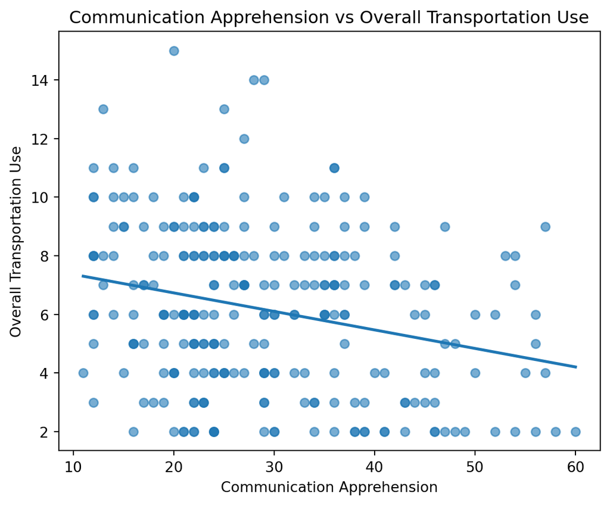

Figure 3: Communication apprehension vs. overall transportation use, with fitted linear trend line.

```python
plot_df = df[["Apprehension", "TransportationUse"]].replace([np.inf, -np.inf], np.nan).dropna()

plt.figure(figsize=(6,5))

plt.scatter(
    plot_df["Apprehension"],
    plot_df["TransportationUse"],
    alpha=0.6
)

coef = np.polyfit(
    plot_df["Apprehension"],
    plot_df["TransportationUse"],
    1
)

x = np.linspace(
    plot_df["Apprehension"].min(),
    plot_df["Apprehension"].max(),
    100
)

plt.plot(
    x,
    coef[0]*x + coef[1],
    linewidth=2
)

plt.xlabel("Communication Apprehension")
plt.ylabel("Overall Transportation Use")
plt.title("Communication Apprehension vs Overall Transportation Use")

plt.tight_layout()
plt.savefig(
    "communication_apprehension_Transportation.png",
    dpi=300,
    bbox_inches="tight"
)
plt.show()
```

Overall transportation use also exhibits a weak negative relationship with communication apprehension. The fitted trend line indicates that participants with higher communication apprehension generally reported lower overall transportation use.

### Overall Interpretation

Among the three visualizations, the scatterplots with fitted linear trend lines provide a simple and effective strategy for illustrating the relationship between communication apprehension and transportation use. The fitted line makes the overall direction of the relationship immediately visible, while the scatter of the individual observations conveys the amount of variability present in the data.

Across all three outcomes, the visualizations suggest weak negative associations between communication apprehension and transportation use. The relationship appears to be most evident when overall transportation use is considered, although none of the figures indicates a strong linear association.

## What questions or uncertainties remain?

These conclusions are based on visual inspection rather than formal statistical inference. The transportation measures are derived from ordinal survey responses, so the fitted linear trend lines should be interpreted as descriptive summaries rather than evidence of a causal relationship. Future analyses could quantify these relationships using nonparametric methods, such as Spearman’s rank correlation, and investigate whether demographic characteristics or transportation accessibility influence these patterns.